# R Notebook to explore the NOAA Storm Database

## Summary

The basic goal of this assignment is to explore the NOAA Storm Database and answer some basic questions about severe weather events.

The analysis addresses the following questions:

1. Across the United States, which types of events (as indicated in the EVTYPE variable) are most harmful with respect to population health?
2. Across the United States, which types of events have the greatest economic consequences?

We charge the libraries that we will use during the calculations and ploting

```r
library(ggplot2)
library(dplyr) # to use case_when function
```

## Data Processing

Fisrt we charge the data provided that can be found zipped in [Data Storm](https://d396qusza40orc.cloudfront.net/repdata%2Fdata%2FStormData.csv.bz2)

```r
stormData <- read.csv("repdata_data_StormData.csv",na.strings="", sep=",", head=TRUE)
# show the first rows of data
head(stormData)
```

|  | STATE__ | BGN_DATE | BGN_TIME | TIME_ZONE | COUNTY | COUNTYNAME | STATE | EVTYPE | BGN_RANGE | BGN_AZI | BGN_LOCATI | END_DATE | END_TIME | COUNTY_END | COUNTYENDN | END_RANGE | END_AZI | END_LOCATI | LENGTH | WIDTH | F | MAG | FATALITIES | INJURIES | PROPDMG | PROPDMGEXP | CROPDMG | CROPDMGEXP | WFO | … |
| --- | --- | --- | --- | --- | --- | --- | --- | --- | --- | --- | --- | --- | --- | --- | --- | --- | --- | --- | --- | --- | --- | --- | --- | --- | --- | --- | --- | --- | --- | --- |
| 1 | 1 | 4/18/1950 0:00:00 | 0130 | CST | 97 | MOBILE | AL | TORNADO | 0 | NA | NA | NA | NA | 0 | NA | 0 | NA | NA | 14.0 | 100 | 3 | 0 | 0 | 15 | 25.0 | K | 0 | NA | NA | … |
| 2 | 1 | 4/18/1950 0:00:00 | 0145 | CST | 3 | BALDWIN | AL | TORNADO | 0 | NA | NA | NA | NA | 0 | NA | 0 | NA | NA | 2.0 | 150 | 2 | 0 | 0 | 0 | 2.5 | K | 0 | NA | NA | … |
| 3 | 1 | 2/20/1951 0:00:00 | 1600 | CST | 57 | FAYETTE | AL | TORNADO | 0 | NA | NA | NA | NA | 0 | NA | 0 | NA | NA | 0.1 | 123 | 2 | 0 | 0 | 2 | 25.0 | K | 0 | NA | NA | … |
| 4 | 1 | 6/8/1951 0:00:00 | 0900 | CST | 89 | MADISON | AL | TORNADO | 0 | NA | NA | NA | NA | 0 | NA | 0 | NA | NA | 0.0 | 100 | 2 | 0 | 0 | 2 | 2.5 | K | 0 | NA | NA | … |
| 5 | 1 | 11/15/1951 0:00:00 | 1500 | CST | 43 | CULLMAN | AL | TORNADO | 0 | NA | NA | NA | NA | 0 | NA | 0 | NA | NA | 0.0 | 150 | 2 | 0 | 0 | 2 | 2.5 | K | 0 | NA | NA | … |
| 6 | 1 | 11/15/1951 0:00:00 | 2000 | CST | 77 | LAUDERDALE | AL | TORNADO | 0 | NA | NA | NA | NA | 0 | NA | 0 | NA | NA | 1.5 | 177 | 2 | 0 | 0 | 6 | 2.5 | K | 0 | NA | NA | … |

Explore the names of the columns to clasify the information.

```r
names(stormData)
```

```
 [1] "STATE__"    "BGN_DATE"   "BGN_TIME"   "TIME_ZONE"  "COUNTY"
 [6] "COUNTYNAME" "STATE"      "EVTYPE"     "BGN_RANGE"  "BGN_AZI"
[11] "BGN_LOCATI" "END_DATE"   "END_TIME"   "COUNTY_END" "COUNTYENDN"
[16] "END_RANGE"  "END_AZI"    "END_LOCATI" "LENGTH"     "WIDTH"
[21] "F"          "MAG"        "FATALITIES" "INJURIES"   "PROPDMG"
[26] "PROPDMGEXP" "CROPDMG"    "CROPDMGEXP" "WFO"        "STATEOFFIC"
[31] "ZONENAMES"  "LATITUDE"   "LONGITUDE"  "LATITUDE_E" "LONGITUDE_"
[36] "REMARKS"    "REFNUM"
```

[output not shown]

[output cut: 18 more lines]

[output not shown]

We see that for the firs question we are interested in the INJURIES and FATALITIES columns. For the second question we are interested in the “damage” columns (PROPDMG and CROPDMG).

First then we group the information by EVTYPE to have a reduced group adding the fatalities and injuries in two dataframes and order the values descending

```r
eventFatalities <- aggregate(FATALITIES~EVTYPE, data=stormData, sum)
eventFatalities <- eventFatalities[order(-eventFatalities$FATALITIES),]

eventInjuries <- aggregate(INJURIES~EVTYPE, data=stormData, sum)
eventInjuries<-eventInjuries[order(-eventInjuries$INJURIES),]

eventFatalitiesAndInjuries <-aggregate((INJURIES +FATALITIES )~EVTYPE, data=stormData, sum)

eventFatalitiesAndInjuries<-eventFatalitiesAndInjuries[order(-eventFatalitiesAndInjuries$`(INJURIES + FATALITIES)`),]
```

We take only the ten greater values for fatalities and injuries to plot the values in the results section.

```r
teneventFatalities <- head(eventFatalities, 10)
teneventInjuries <-head(eventInjuries, 10)
```

## Results

From data procesing we see the most severe events, however a ploting is added to show it graphically.

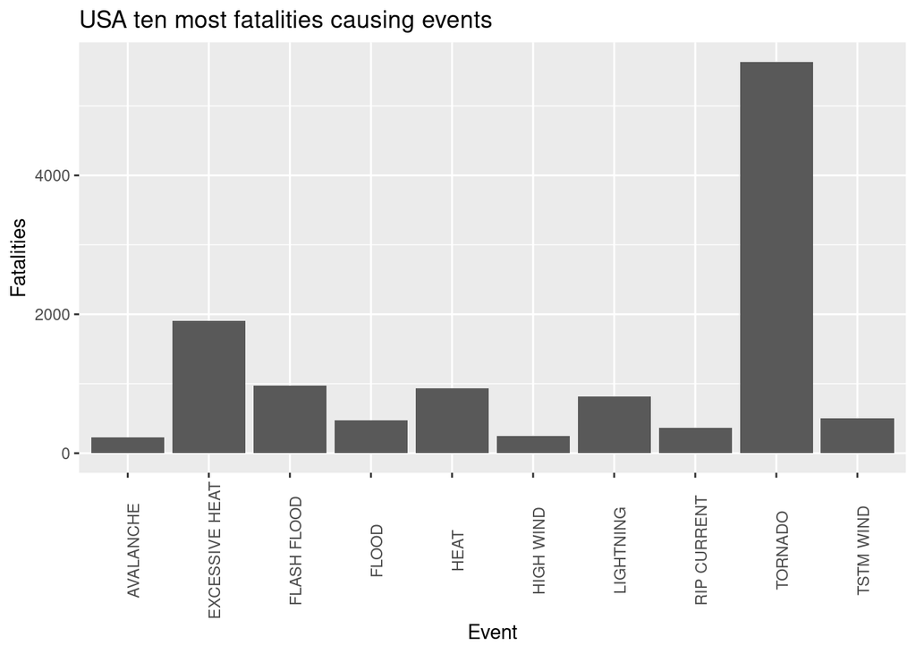

```r
ggplot(data=teneventFatalities, aes(x=teneventFatalities$EVTYPE, y=teneventFatalities$FATALITIES)) +
    geom_bar(stat="identity",position=position_dodge()) +
    theme(axis.text.x = element_text(angle = 90)) +
    labs(x = "Event", y = "Fatalities", title = "USA ten most fatalities causing events")
```

The tornado is with great different the worst event followed by excesive heat and flash flood.

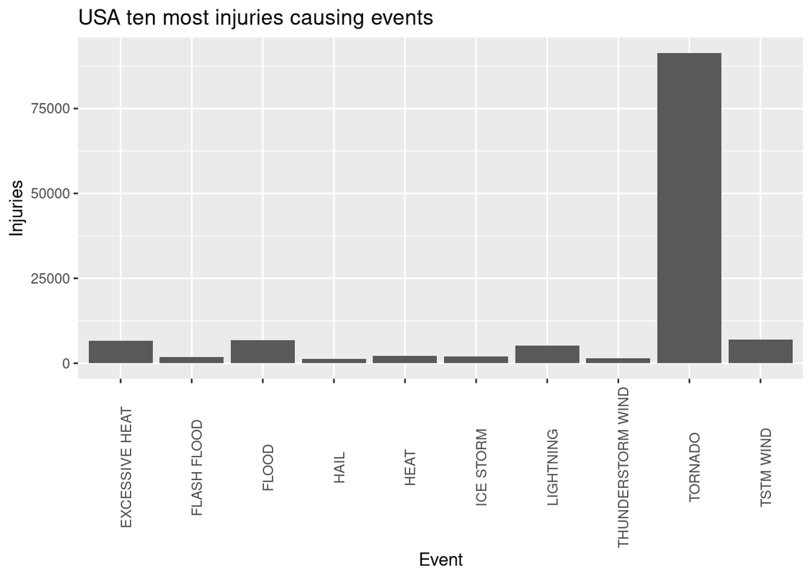

```r
ggplot(data=teneventInjuries, aes(x=teneventInjuries$EVTYPE, y=teneventInjuries$INJURIES)) +
    geom_bar(stat="identity",position=position_dodge()) +
    theme(axis.text.x = element_text(angle = 90)) +
    labs(x = "Event", y = "Injuries", title = "USA ten most injuries causing events")
```

For injuries, the tornado, followed by TSTM Wind, Flood and excessive Heat. To keep the worst combined we just show the sum of both.

```r
head(eventFatalitiesAndInjuries, 10)
```

|  | EVTYPE | (INJURIES + FATALITIES) |
| --- | --- | --- |
| 834 | TORNADO | 96979 |
| 130 | EXCESSIVE HEAT | 8428 |
| 856 | TSTM WIND | 7461 |
| 170 | FLOOD | 7259 |
| 464 | LIGHTNING | 6046 |
| 275 | HEAT | 3037 |
| 153 | FLASH FLOOD | 2755 |
| 427 | ICE STORM | 2064 |
| 760 | THUNDERSTORM WIND | 1621 |
| 972 | WINTER STORM | 1527 |

We consider then those values as the worst combining Injuries + fatalities.

For the second question we are going just to agregate all the damages and sort the worst events. Before doing the sum, we read in page 12 of the [Storm Data Documentation](https://d396qusza40orc.cloudfront.net/repdata%2Fpeer2_doc%2Fpd01016005curr.pdf) And see that we have to convert to the same units before summing the values.

First we generate a copy of the dataframe and find different values to convert (from names we find the index of PROPDMGEXP and CROPDMGEXP)

```r
eventsDamage <-stormData
unique(eventsDamage[,28] )
```

```
[1] <NA> M    K    m    B    ?    0    k    2
Levels: ? 0 2 B k K m M
```

```r
unique(eventsDamage[,26] )
```

```
 [1] K    M    <NA> B    m    +    0    5    6    ?    4    2    3    h
[15] 7    H    -    1    8
Levels: - ? + 0 1 2 3 4 5 6 7 8 B h H K m M
```

We generate a new column in the data set with the value in dolars of each damage to properties and crops and after that, we agregate the values in billions of dolars.

```r
eventsDamage <-eventsDamage %>% mutate(damageprop = case_when(is.na(PROPDMGEXP) ~ PROPDMG,
                                           PROPDMGEXP=="K" ~ 1000*PROPDMG,
                                           PROPDMGEXP=="k" ~ 1000*PROPDMG,
                                           PROPDMGEXP=="M" ~ 1000000*PROPDMG,
                                           PROPDMGEXP=="m" ~ 1000000*PROPDMG,
                                           PROPDMGEXP=="B" ~ PROPDMG*1000000000,
                                           FALSE ~ PROPDMG))
eventsDamage <-eventsDamage %>% mutate(damagecrop = case_when(is.na(CROPDMGEXP) ~ CROPDMG,
                                           CROPDMGEXP=="K" ~ 1000*CROPDMG,
                                           CROPDMGEXP=="k" ~ 1000*CROPDMG,
                                           CROPDMGEXP=="M" ~ 1000000*CROPDMG,
                                           CROPDMGEXP=="m" ~ 1000000*CROPDMG,
                                           CROPDMGEXP=="B" ~ CROPDMG*1000000000,
                                           FALSE ~ CROPDMG))

#Agregate the damage in billions of Dolars
eventsDamage <-aggregate((damageprop+damagecrop)/1000000000~EVTYPE, data=eventsDamage, sum)
names(eventsDamage)[2]<- "damage"
eventsDamageOrdered<- eventsDamage[order(-eventsDamage$damage),]

head(eventsDamageOrdered, 10)
```

|  | EVTYPE | damage |
| --- | --- | --- |
| 168 | FLOOD | 150.319678 |
| 407 | HURRICANE/TYPHOON | 71.913713 |
| 830 | TORNADO | 57.301936 |
| 666 | STORM SURGE | 43.323541 |
| 241 | HAIL | 18.733216 |
| 152 | FLASH FLOOD | 17.561539 |
| 94 | DROUGHT | 15.018672 |
| 398 | HURRICANE | 14.610229 |
| 586 | RIVER FLOOD | 10.148404 |
| 423 | ICE STORM | 8.967038 |

The table shows that the FOOD is the event generating the highest economical cost with more than 150 billion dolars.